# Aderência de parlamentares que receberam recurso de grandes doadores

## *Resumo*

Este relatório busca analisar e visualizar dados sobre deputados que receberam doações dos maiores doadores na campanha de 2018. Foi avaliado a aderência de parlamentares ao Governo considerando todas as votações nominais no plenário da Câmara em 2019.

### Quais os partidos dos parlamentares selecionados?

A seguir vamos visualizar quais os partidos que compõem a lista dos 36 parlamentares selecionados para análise.

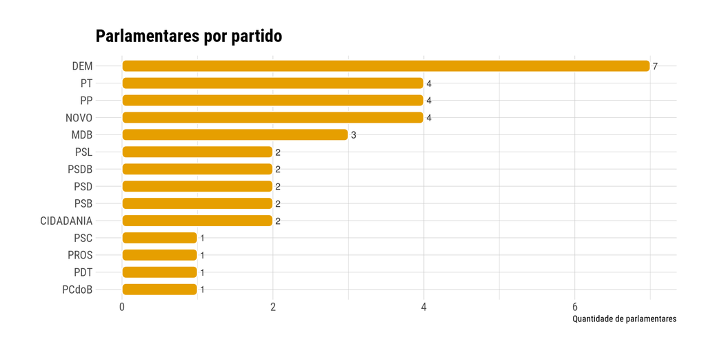

DEM é o partido com mais parlamentares (7) na lista, seguido de PT, PP e NOVO com 4 cada.

### Visualização da Aderência com média

A **Aderência ao Governo** é a razão entre o número de vezes em que seguiu a orientação do governo dividido pelo número de vezes que participou de votações com orientação do governo (tendo seguido ou não essa orientação).

A seguir vemos os parlamentares ordenados pela aderência

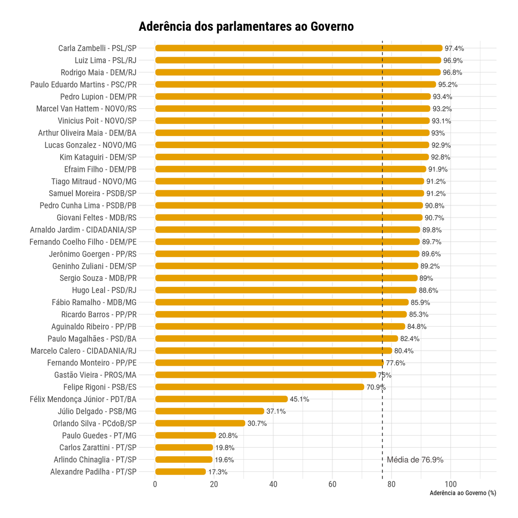

A média na visualização é a média de aderência desses parlamentares selecionados

### Como cada parlamentar seguiu a orientação do Governo?

A seguir iremos analisar a quantidade de votações nas quais os parlamentares seguiram ou não a orientação do Governo.

A visualização a seguir apresenta a distribuição das votações entre os parlamentares considerando aquelas em que seguiu o Governo e aquelas que não seguiu. A ordem dos deputados é definida da maior aderência para a menor.

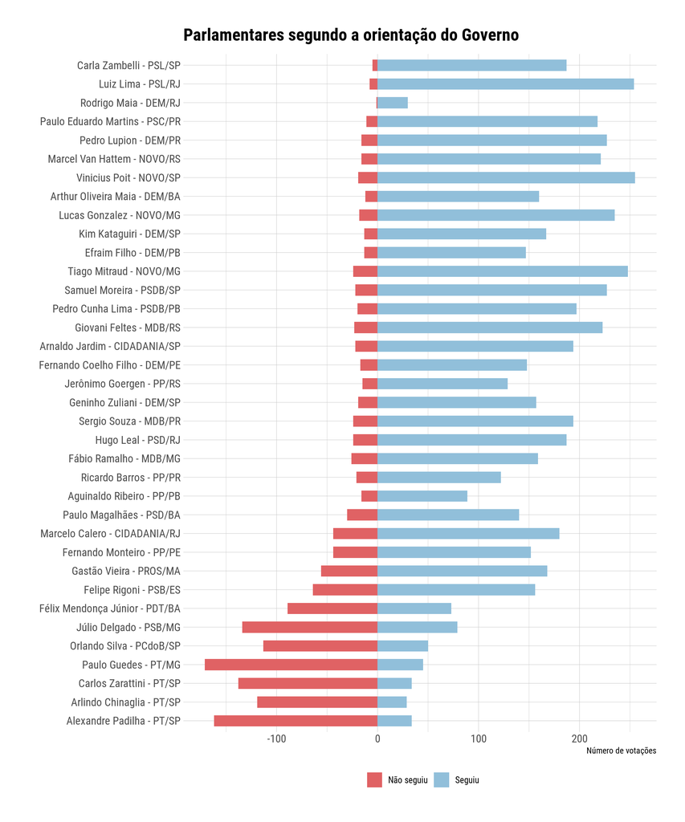

A seguir podemos visualizar mais detalhes de como os parlamentares votaram de acordo com a orientação do Governo.

Rodrigo Maia é um caso especial uma vez que enquanto Presidente da Câmara não participa de todas as votações nominais. Por este motivo foi removido da visualização a seguir. Maia participou de 31 votações, tendo seguido o Governo em 30 delas.

Nesta próxima visualização as votações são destrinchadas considerando mais 2 possibilidades. O deputado não participou da votação ou o Governo não apresentou orientação então o voto é considerado liberado.

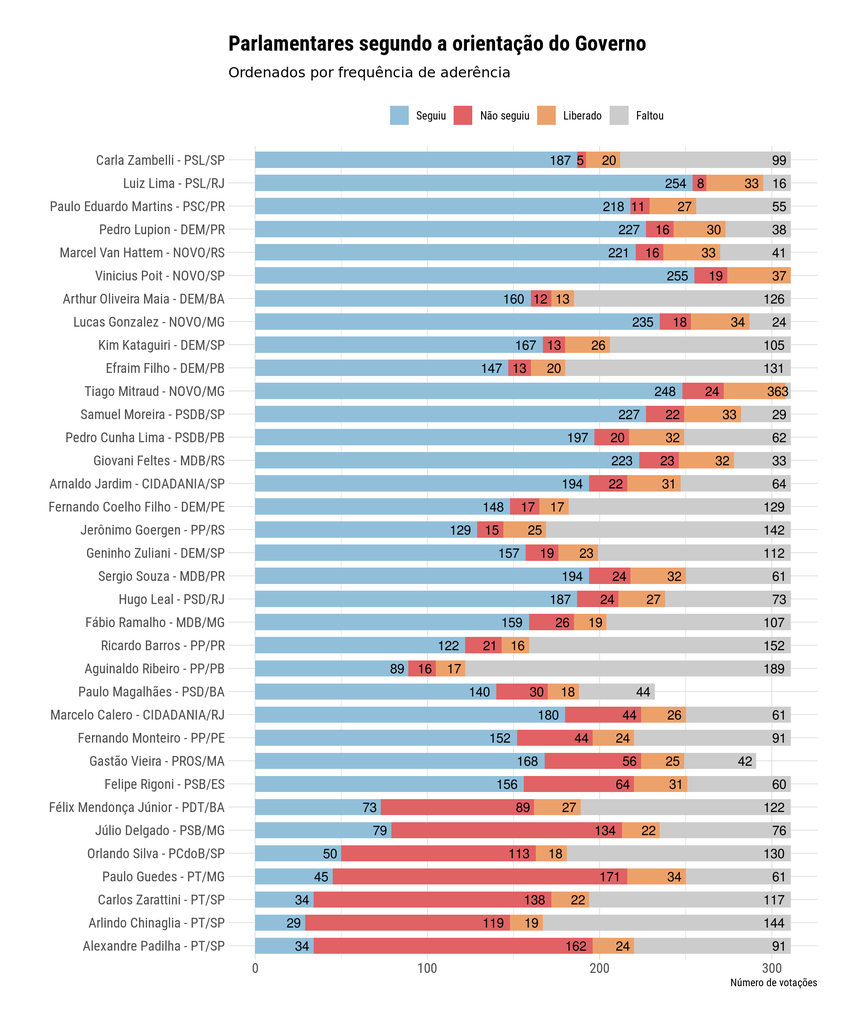

## Dados

Os dados de aderência para os parlamentares selecionados usados nessa análise podem ser conferidos na tabela abaixo.

| id | Nome | Partido | Aderência | Seguiu | Não Seguiu | Faltou | Liberado |
| --- | --- | --- | --- | --- | --- | --- | --- |
| 160527 | Aguinaldo Ribeiro - PP/PB | PP | 84.76 | 89 | 16 | 189 | 17 |
| 73433 | Arlindo Chinaglia - PT/SP | PT | 19.59 | 29 | 119 | 144 | 19 |
| 141391 | Arnaldo Jardim - CIDADANIA/SP | CIDADANIA | 89.81 | 194 | 22 | 64 | 31 |
| 160600 | Arthur Oliveira Maia - DEM/BA | DEM | 93.02 | 160 | 12 | 126 | 13 |
| 141398 | Carlos Zarattini - PT/SP | PT | 19.77 | 34 | 138 | 117 | 22 |
| 141422 | Efraim Filho - DEM/PB | DEM | 91.88 | 147 | 13 | 131 | 20 |
| 141427 | Fábio Ramalho - MDB/MG | MDB | 85.95 | 159 | 26 | 107 | 19 |
| 160666 | Félix Mendonça Júnior - PDT/BA | PDT | 45.06 | 73 | 89 | 122 | 27 |
| 141431 | Fernando Coelho Filho - DEM/PE | DEM | 89.7 | 148 | 17 | 129 | 17 |
| 92699 | Fernando Monteiro - PP/PE | PP | 77.55 | 152 | 44 | 91 | 24 |

[output cut: 26 more lines]

## Aderência em votações de proposições de Agenda Nacional e MPVs

A seguir vamos analisar a aderência ao Governo num subconjunto de proposições que fazem parte da pauta do Governo e que chamamos de Agenda Nacional. Também foram incluídas todas as Medidas Provisórias votadas em 2019.

O subconjunto das proposições analisadas é formado por:  
PL 1292/1995, PEC 70/2011, PEC 2/2015, PLP 441/2017, PL 10431/2018, MPV 852/2018, PL 5029/2019 (Nº Anterior: PL 11021/2018), MPV 861/2018 , MPV 863/2018, MPV 866/2018, MPV 867/2018, MPV 867/2018, MPV 870/2019, MPV 871/2019, PDL 3/2019, PEC 6/2019, PLN 2/2019 CN, PEC 34/2019, MPV 879/2019 , MPV 881/2019, MPV 886/2019 , MPV 889/2019, MPV 890/2019.

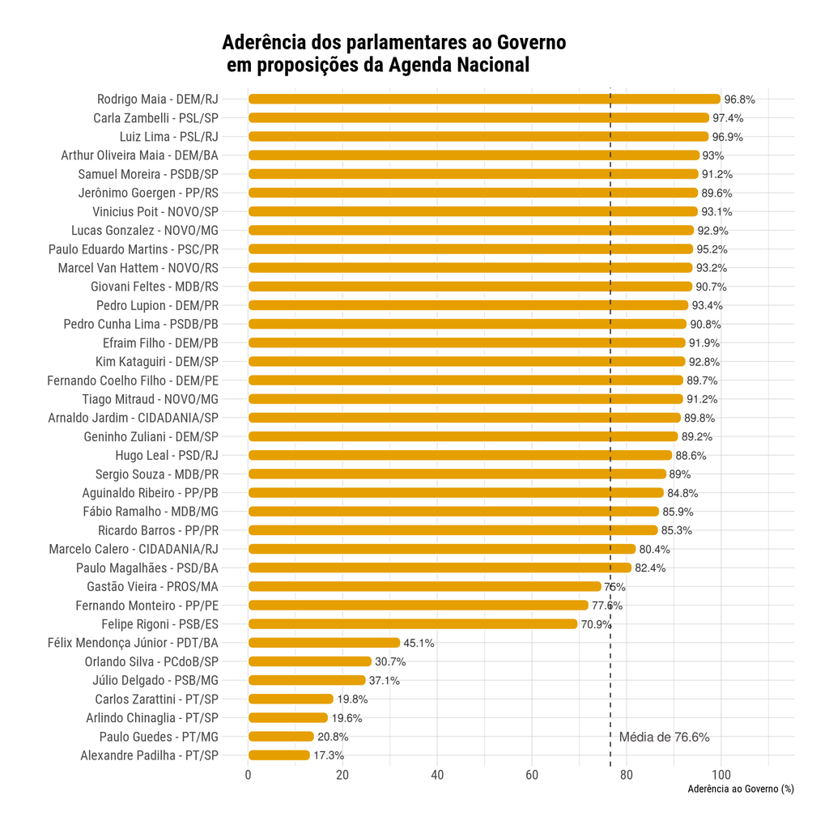

A média na visualização é a média de aderência desses parlamentares selecionados

# Comparando com todos os parlamentares

A seguir vamos comparar a aderência da lista de parlamentares selecionados com todos os demais parlamentares. Aqui foram consideradas **todas as votações nominais no plenário da Câmara** e como o Governo orientou nessas votações.

A visualização abaixo mostra a posição dos parlamentares selecionados com relação a aderência ao Governo em votações nominais.

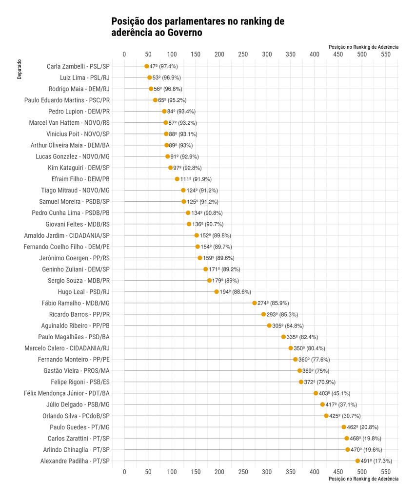

Na visualização é possível conhecer a posição do parlamentar no Ranking de Aderência ao Governo. A aderência ao governo do parlamentar está presente entre parênteses.

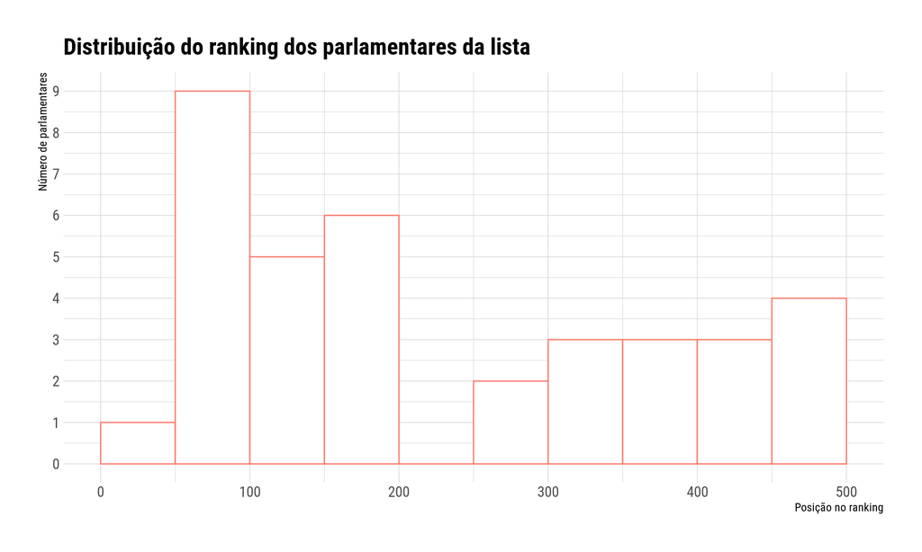

### Aderência por partido

A seguir visualizaremos a posição da aderência dos parlamentares comparados com os demais membros do partido.

Cada marca | na visualização é um parlamentar, os parlamentares em preto são aqueles selecionados por terem recebido doação de grandes doadores. As cores verde e roxo apenas ajudam a diferenciar os partidos entre si. A ordem dos partidos é definida daqueles com maiores médias de aderência para aqueles com menores médias.

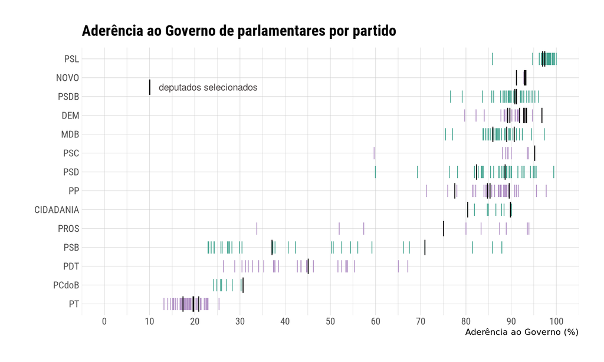

Agora iremos comparar cada um desses deputados selecionados com a média de aderência de seus partidos

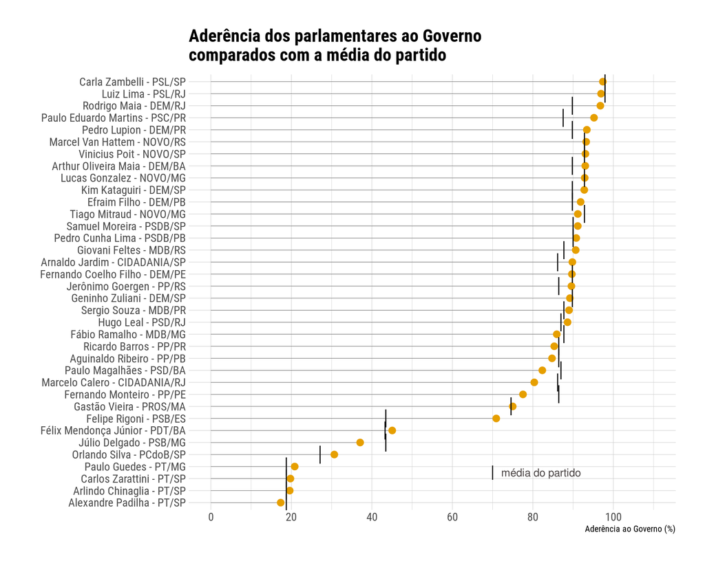

Os pontos amarelos que estão depois da marca | preta indicam os parlamentares que possuem maior aderência ao Governo do que a média dos parlamentares de seu partido.

A seguir outra alternativa de visualização para comparação da aderência ao governo dos parlamentares com a média de seu partido.

Na visualização existem duas barras: **a barra amarela é a aderência do parlamentar ao Governo** enquanto que a **barra azul indica a média do partido**. Quando as duas barras se sobrepõem o resultado é a cor cinza.

Quando o parlamentar possui uma maior aderência ao governo do que a média do partido a cor amarela é cor execedente na visualização. Se a aderência do parlamentar é menor que a média do partido a barra azul será maior que a amarela.

A diferença entre a aderência do parlamentar e a média do partido é dada pela diferença entre a barra cinza (menor valor) e a barra que se sobrepõe (maior valor).

Paulo Eduardo Martins (PSC/PR) possui maior aderência ao governo do que a média de seu partido (barra amarela se destaca). Enquanto que Fernando Monteiro (PP/PE) possui uma aderência ao governo menor que a média de seu partido (barra azul se destaca).

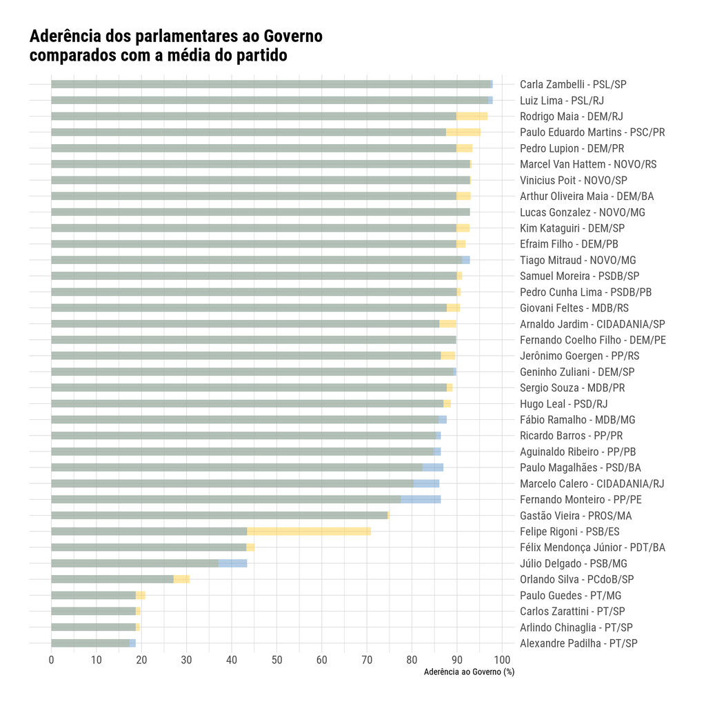

## Dados

Os dados de aderência para os todos os parlamentares usados nessa análise podem ser conferidos na tabela abaixo.

| id | Nome | Partido | Aderência | Seguiu | Não Seguiu | Faltou | Liberado |
| --- | --- | --- | --- | --- | --- | --- | --- |
| 160508 | Afonso Florence - PT/BA | PT | 18.69 | 40 | 174 | 72 | 25 |
| 136811 | Afonso Hamm - PP/RS | PP | 91.56 | 206 | 19 | 55 | 31 |
| 178835 | Afonso Motta - PDT/RS | PDT | 45.11 | 106 | 129 | 52 | 24 |
| 160527 | Aguinaldo Ribeiro - PP/PB | PP | 84.76 | 89 | 16 | 189 | 17 |
| 178836 | Alan Rick - DEM/AC | DEM | 91.34 | 211 | 20 | 48 | 32 |
| 160559 | Alceu Moreira - MDB/RS | MDB | 97.35 | 184 | 5 | 103 | 19 |
| 160511 | Alessandro Molon - PSB/RJ | PSB | 22.95 | 42 | 141 | 109 | 19 |
| 178972 | Alex Manente - CIDADANIA/SP | CIDADANIA | 84.97 | 130 | 23 | 141 | 17 |
| 160545 | Alexandre Leite - DEM/SP | DEM | 88.51 | 208 | 27 | 46 | 30 |
| 178833 | Alexandre Serfiotis - PSD/RJ | PSD | 83.72 | 180 | 35 | 65 | 31 |

[output cut: 503 more lines]

## Comparação da distribuição de cargos na Câmara

Na seção a seguir iremos abordar como os cargos dos parlamentares da lista pode ser comparado com os demais parlamentares da Câmara. Para isto iremos considerar:

- **cargos de liderança em partidos/bancadas**
- **cargos de titularidade em comissões permamentes**
- **cargos na mesa diretora da Câmara**

Consideramos cargos de lideranças em partidos como sendo cargos de líder ou vice-líder nos partidos e bancadas da Câmara.

Na tabela a seguir mostra para os parlamentares da lista a comparação entre o nº de cargos que ele possui e qual a média que um parlamentar da Câmara teria distribuindo os 900 cargos analisados entre os 513 deputados.

| id | Nome | Partido | UF | Nº de cargos | Média de cargos da Câmara |
| --- | --- | --- | --- | --- | --- |
| 204503 | Alexandre Padilha - PT/SP | PT | SP | 4 | 1.75 |
| 141427 | Fábio Ramalho - MDB/MG | MDB | MG | 3 | 1.75 |
| 156190 | Marcel Van Hattem - NOVO/RS | NOVO | RS | 3 | 1.75 |
| 204492 | Paulo Guedes - PT/MG | PT | MG | 3 | 1.75 |
| 160527 | Aguinaldo Ribeiro - PP/PB | PP | PB | 2 | 1.75 |
| 73433 | Arlindo Chinaglia - PT/SP | PT | SP | 2 | 1.75 |
| 141422 | Efraim Filho - DEM/PB | DEM | PB | 2 | 1.75 |
| 92699 | Fernando Monteiro - PP/PE | PP | PE | 2 | 1.75 |
| 141450 | Hugo Leal - PSD/RJ | PSD | RJ | 2 | 1.75 |
| 178912 | Pedro Cunha Lima - PSDB/PB | PSDB | PB | 2 | 1.75 |

[output cut: 26 more lines]

Os primeiros 15 parlamentares possuem mais cargos do que a média da Câmara. Os demais parlamentares possuem apenas 1 cargo.